# initial_r2_only

Sarah Hazell Pickering

2024-08-26

Quality control and Mt filtering for adipogenesis scRNAseq (gene-level). More specific analyses white_only and white_vs_beige come start from this seurat object.

Cellranger was run on day1 and day3 samples in “read2 only” mode, to match the way the second replicate was sequenced. I’ve just linked day0 from donor6 into the same directory, will replace if necessary, but since day0 cells are so different, it shouldn’t make a difference that they were processed in PE mode.

Goal: to assess if R2 only mode removed the replicate differences at day 1 (it minimised them yes).

```r
library(BPCells)
library(Seurat)
library(clusterProfiler)
library(dplyr)
library(enrichplot)
library(ggplot2)
library(here)
library(patchwork)
```

```r
module = "adipogenesis"
dataname = "initial_r2_only"
load_data = F #load 10x counts on first run through
subset_data = F

rmd_filename = "adipogenesis_initial_r2_only"
i_am(file.path("analysis", module, paste0(rmd_filename,".Rmd")))
```

```
## here() starts at /projects/imb-pkbphil/sp/sc_rnaseq/progenitor_scrnaseq
```

```r
indir = here("data/cellranger/count_r2_only") #links atm; todo: link to GEO counts
odir = here("output", module, dataname)
```

```r
set.seed(8)
fig_dir = here("analysis", module, "figures", rmd_filename)
if (!dir.exists(fig_dir)) dir.create(fig_dir, recursive = TRUE)
knitr::opts_chunk$set(fig.path = paste0(fig_dir, "/"),
                      dev = c("png","pdf"))

if (!dir.exists(odir)) dir.create(odir, recursive = TRUE)
```

```r
theme_hp = theme_classic(base_size = 15) +
  theme(axis.line = element_line(linewidth = 0.25),
        axis.ticks = element_line(linewidth = 0.25),
        strip.background = element_blank())
theme_set(theme_hp)
pal = c("#1F78B4", "#B2DF8A","#85C2EA", "#B3B3B3","#F18486","#FDBF6F","#E31A1C")
clusters = tvthemes::gravityFalls_pal()(13)
spectral = rev(RColorBrewer::brewer.pal(n = 11, name = "Spectral"))
```

## Read data

```r
samples = list.dirs(here(indir), full.names = F, recursive = F)

if (load_data==FALSE){# load count matrices

  data_list = c()

  for (s in samples){
    #if this has been run before delete bp dir
    bc_matrix = Read10X(data.dir = here(indir, s, "outs/filtered_feature_bc_matrix"))
    so = CreateSeuratObject(counts=bc_matrix, project=s, names.field = 2, names.delim = "-")
    write_matrix_dir(mat=so[["RNA"]]$counts, dir = here(odir, "bpcells", s))
    gene_mat = open_matrix_dir(here(odir, "bpcells", s))
    so[["RNA"]]$counts = gene_mat

    data_list = c(data_list,so)
  }
  names(data_list) = samples
  aggr = merge(data_list[[1]], y= data_list[2:length(data_list)],
               add.cell.ids = gsub("_",".",samples), project=dataname )

  saveRDS(aggr,here(odir, "unfiltered_object.rds"))

  rm(data_list, bc_matrix, so)
} else if(load_data){
  aggr = readRDS(here(odir, "unfiltered_object.rds"))
}
aggr
```

```
## An object of class Seurat
## 36601 features across 60157 samples within 1 assay
## Active assay: RNA (36601 features, 0 variable features)
##  7 layers present: counts.asc_day0, counts.beige_day1, counts.beige_day1_rep2, counts.beige_day3, counts.white_day1, counts.white_day1_rep2, counts.white_day3
```

```r
head(aggr@meta.data) #auto metadata
```

```
##                             orig.ident nCount_RNA nFeature_RNA
## asc.day0_AAACCTGAGAATAGGG-1          1      33853         5322
## asc.day0_AAACCTGAGAGGGCTT-1          1      46014         6656
## asc.day0_AAACCTGAGATCGATA-1          1      33328         5355
## asc.day0_AAACCTGAGGTAGCTG-1          1      25327         4802
## asc.day0_AAACCTGAGGTGCTAG-1          1      31012         5750
## asc.day0_AAACCTGAGTTGTAGA-1          1      35590         6193
```

```r
aggr$orig.ident = gsub("\\.","_",gsub("_.*", "",rownames(aggr@meta.data)))
aggr$orig.ident = factor(aggr$orig.ident, levels = c("white_day3","white_day1_rep2","white_day1","asc_day0",
                                                     "beige_day1","beige_day1_rep2","beige_day3"))
Idents(aggr) = aggr$orig.ident
aggr$sample = aggr$orig.ident
table(aggr@meta.data$orig.ident)
```

```
##
##      white_day3 white_day1_rep2      white_day1        asc_day0      beige_day1
##           11649           12922            6140            7553            2691
## beige_day1_rep2      beige_day3
##            5266           13936
```

```r
aggr$condition = gsub("_.*","", aggr$orig.ident)
table(aggr$condition)
```

```
##
##   asc beige white
##  7553 21893 30711
```

```r
aggr$time = gsub(".*_", "", gsub("_rep2","",aggr$orig.ident))
table(aggr$time)
```

```
##
##  day0  day1  day3
##  7553 27019 25585
```

```r
aggr$rep = "rep1"
aggr$rep[grep("_rep2", aggr$orig.ident)] = "rep2"
```

```r
aggr <- JoinLayers(aggr)
aggr
```

```
## An object of class Seurat
## 36601 features across 60157 samples within 1 assay
## Active assay: RNA (36601 features, 0 variable features)
##  1 layer present: counts
```

```r
if (subset_data){
  aggr = subset(aggr, downsample=1000)
  print(aggr)
}
```

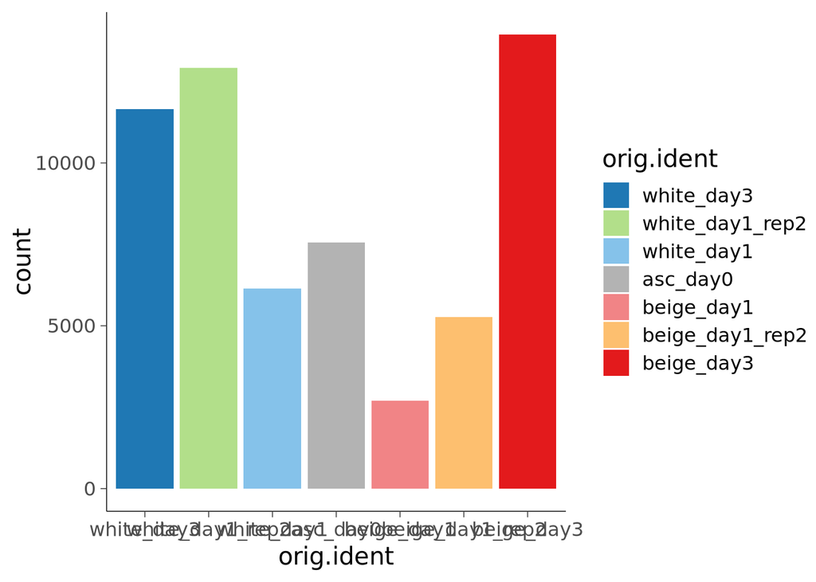

```r
ggplot(aggr@meta.data) + geom_bar(aes(x=orig.ident, fill=orig.ident)) + scale_fill_manual(values=pal)
```

## Quality control and Filtering

Number of genes (features) detected per cell high, due to the depth of our sequencing and the stem-cell nature of the samples. There is a wide spread of the number of genes (nFeature)and reads (nCount) per cell. The percentage mitochondrial genes is super low for most cells, but some few have up to 80% mt.

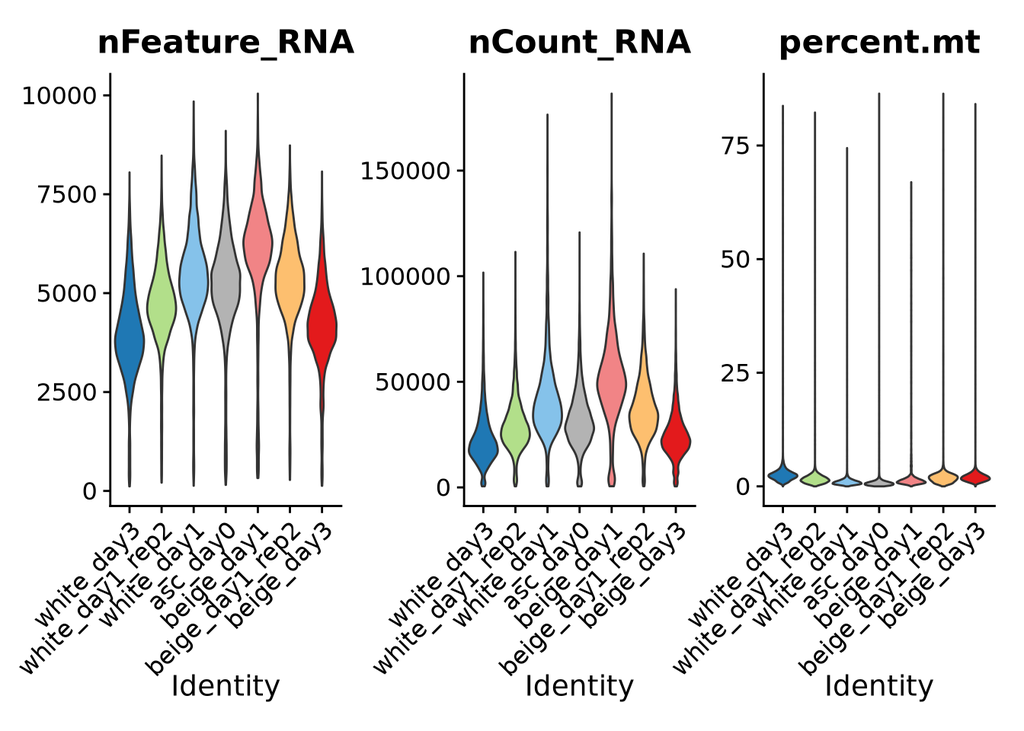

```r
aggr[["percent.mt"]] = PercentageFeatureSet(aggr, pattern="^MT-")
VlnPlot(aggr, features = c("nFeature_RNA", "nCount_RNA", "percent.mt"), ncol = 3, pt.size = 0, cols=pal)
```

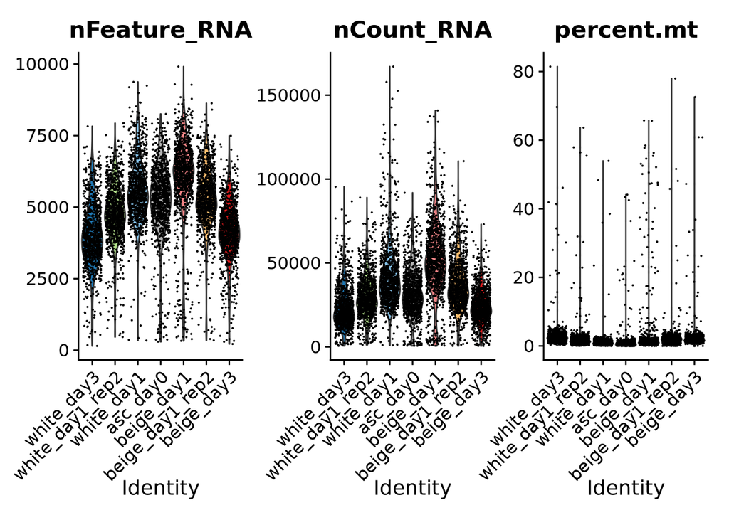

```r
VlnPlot(subset(x = aggr, downsample = 1000), features = c("nFeature_RNA", "nCount_RNA", "percent.mt"), ncol = 3, cols=pal)
```

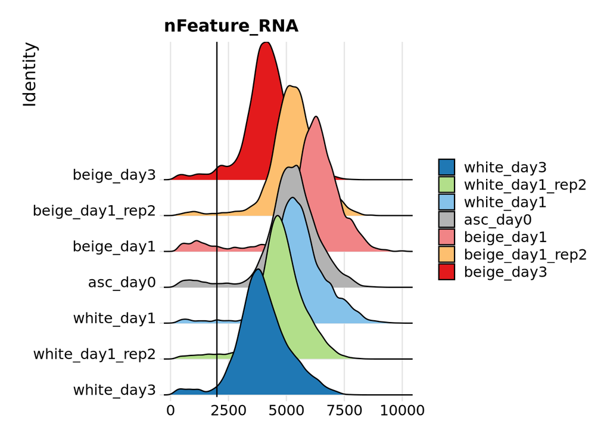

```r
RidgePlot(aggr, feature= "nFeature_RNA", cols=pal) + geom_vline(aes(xintercept=2000))
```

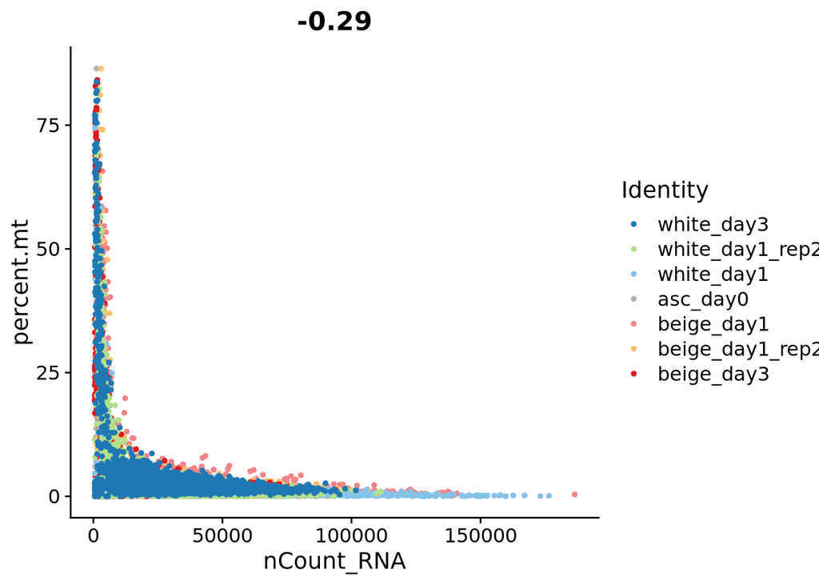

```r
FeatureScatter(aggr, feature1 = "nCount_RNA", feature2 = "percent.mt", cols=pal)
```

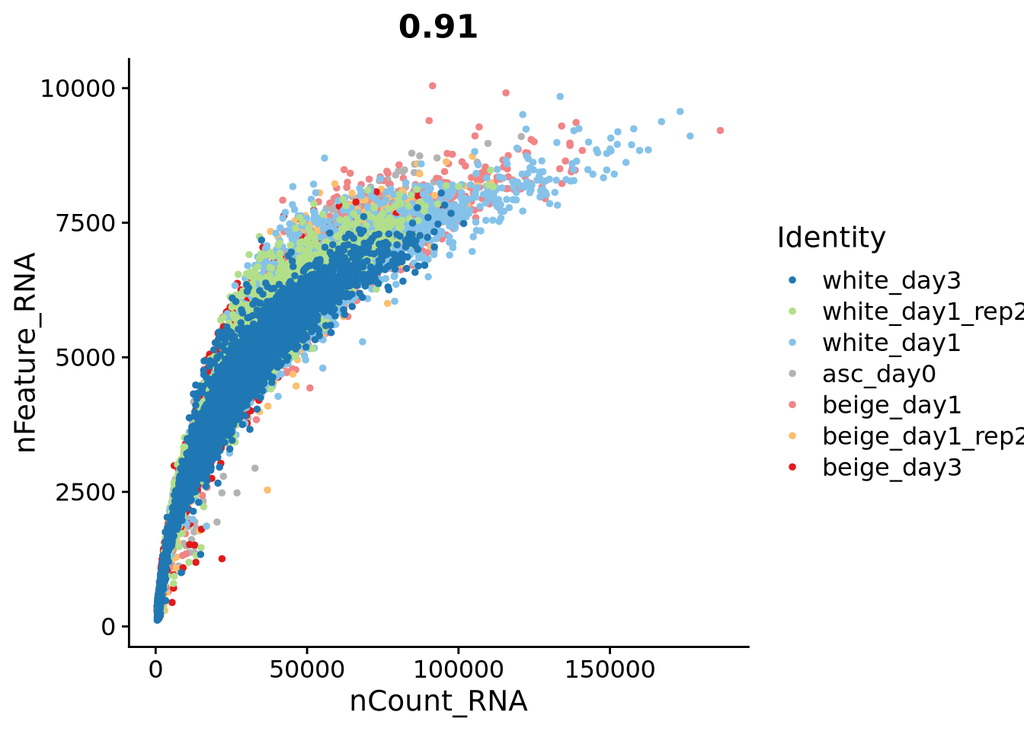

```r
FeatureScatter(aggr, feature1 = "nCount_RNA", feature2 = "nFeature_RNA", cols=pal)
```

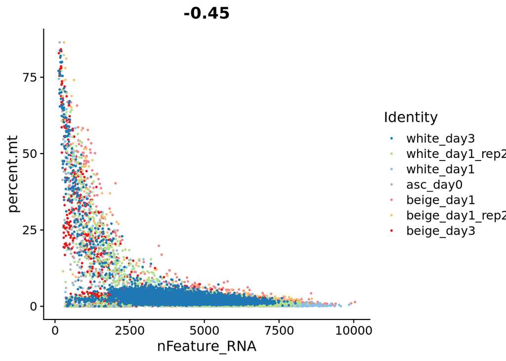

```r
FeatureScatter(aggr, feature1 = "nFeature_RNA", feature2 = "percent.mt", pt.size = 0.5, cols=pal)
```

We set an adaptive Mt.percent filter that’s the 3* mad maximum.

```r
mt_info = group_by(aggr@meta.data, sample) %>%
  summarise(mad = mad(percent.mt),
            median = median(percent.mt),
            thresh = median(percent.mt) + mad(percent.mt)*3,
            th95 = quantile(percent.mt, 0.95))
mt_info
```

```
## # A tibble: 7 × 5
##   sample            mad median thresh  th95
##   <fct>           <dbl>  <dbl>  <dbl> <dbl>
## 1 white_day3      0.987  2.40    5.36  4.84
## 2 white_day1_rep2 0.844  1.51    4.05  3.38
## 3 white_day1      0.504  0.867   2.38  2.19
## 4 asc_day0        0.450  0.645   2.00  1.77
## 5 beige_day1      0.640  1.17    3.09  8.15
## 6 beige_day1_rep2 0.964  1.84    4.73  3.54
## 7 beige_day3      0.806  1.91    4.33  3.65
```

```r
thresh = max(mt_info$thresh)
```

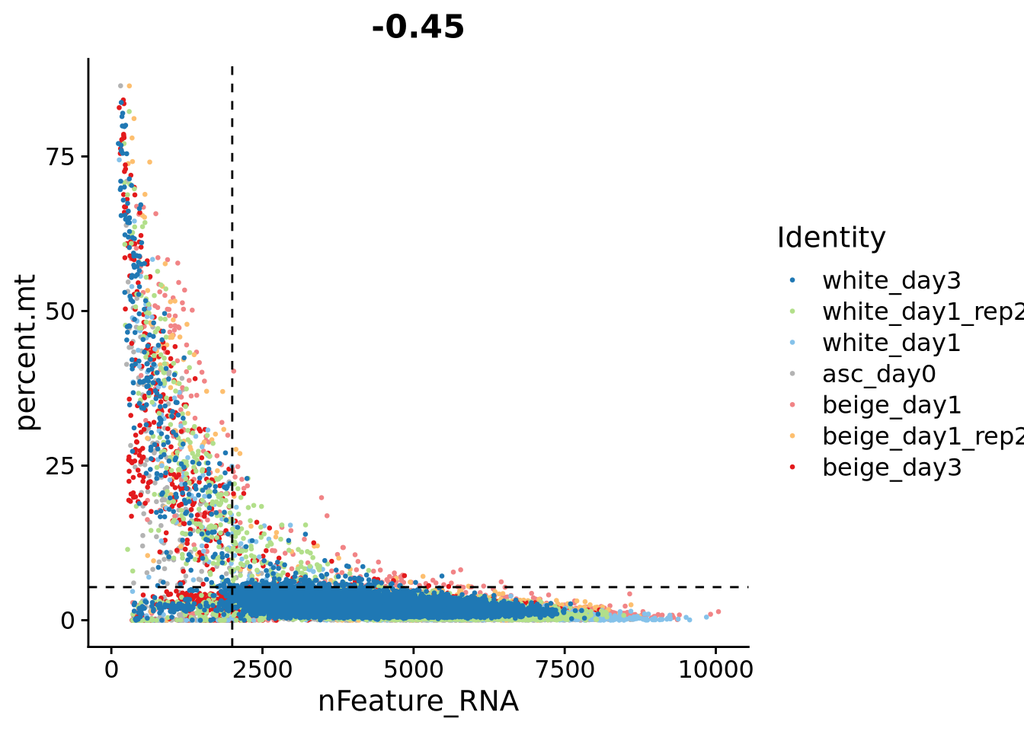

```r
FeatureScatter(aggr, feature1 = "nFeature_RNA", feature2 = "percent.mt", pt.size = 0.5, cols=pal) +
  geom_hline(aes(yintercept=thresh), linetype="dashed") +
  geom_vline(aes(xintercept=2000), linetype="dashed")
```

```r
ncol(aggr)
```

```
## [1] 60157
```

```r
filt <- subset(aggr,  percent.mt < thresh & nFeature_RNA > 2000)
ncol(filt)
```

```
## [1] 57882
```

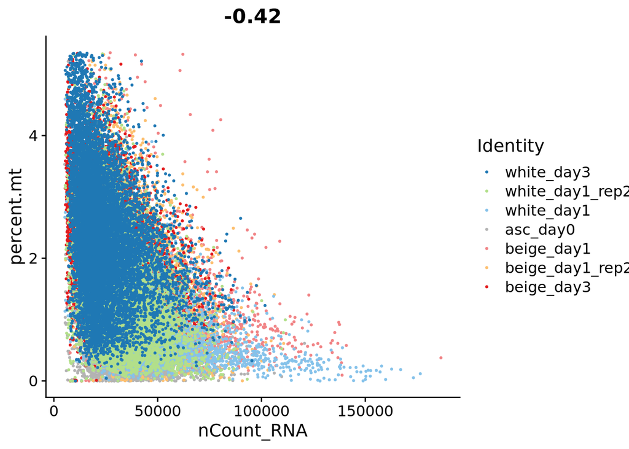

```r
FeatureScatter(filt, feature1 = "nCount_RNA", feature2 = "percent.mt", pt.size=0.5, cols=pal)
```

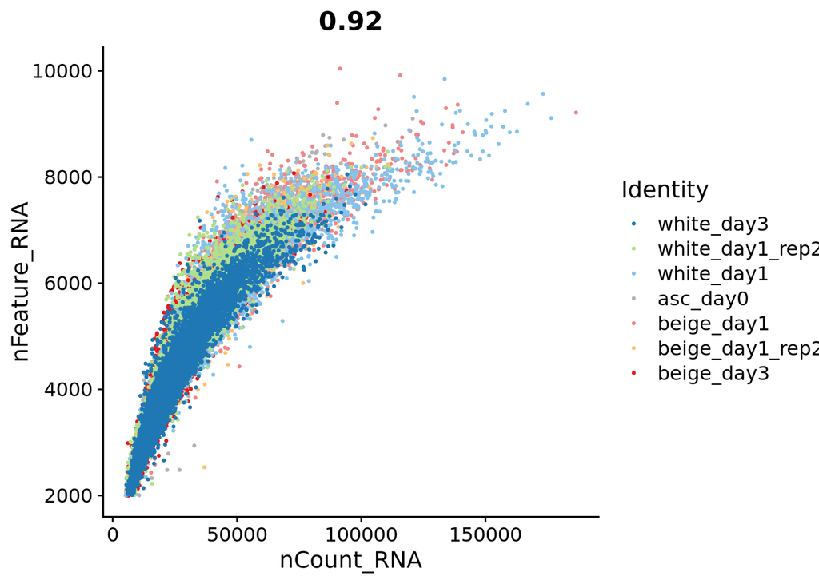

```r
FeatureScatter(filt, feature1 = "nCount_RNA", feature2 = "nFeature_RNA", pt.size=0.5, cols=pal)
```

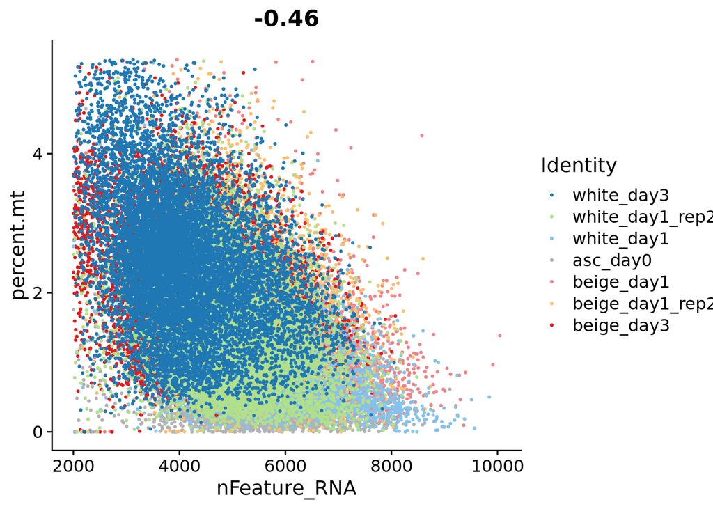

```r
FeatureScatter(filt, feature1 = "nFeature_RNA", feature2 = "percent.mt", pt.size = 0.5, cols=pal)
```

## Normalisation

Feature counts for each cell are divided by the total counts for that cell and multiplied by the scale.factor. This is then natural-log transformed using log1p

```r
filt= NormalizeData(filt, normalization.method = "LogNormalize", scale.factor = 10000)
```

```
## Normalizing layer: counts
```

```r
filt#161Mb
```

```
## An object of class Seurat
## 36601 features across 57882 samples within 1 assay
## Active assay: RNA (36601 features, 0 variable features)
##  2 layers present: counts, data
```

```r
all.genes = rownames(filt)
filt = ScaleData(filt, features=all.genes)
```

```r
filt <- FindVariableFeatures(filt, selection.method = "vst", nfeatures = 2000)
```

```
## Finding variable features for layer counts
```

```r
filt #163Mb
```

```
## An object of class Seurat
## 36601 features across 57882 samples within 1 assay
## Active assay: RNA (36601 features, 2000 variable features)
##  3 layers present: counts, data, scale.data
```

```r
# Identify the 10 most highly variable genes
top10 <- head(VariableFeatures(filt), 10)

# plot variable features with and without labels
plot1 = VariableFeaturePlot(filt)
plot2 <- LabelPoints(plot = plot1, points = top10, repel = TRUE)
```

```
## When using repel, set xnudge and ynudge to 0 for optimal results
```

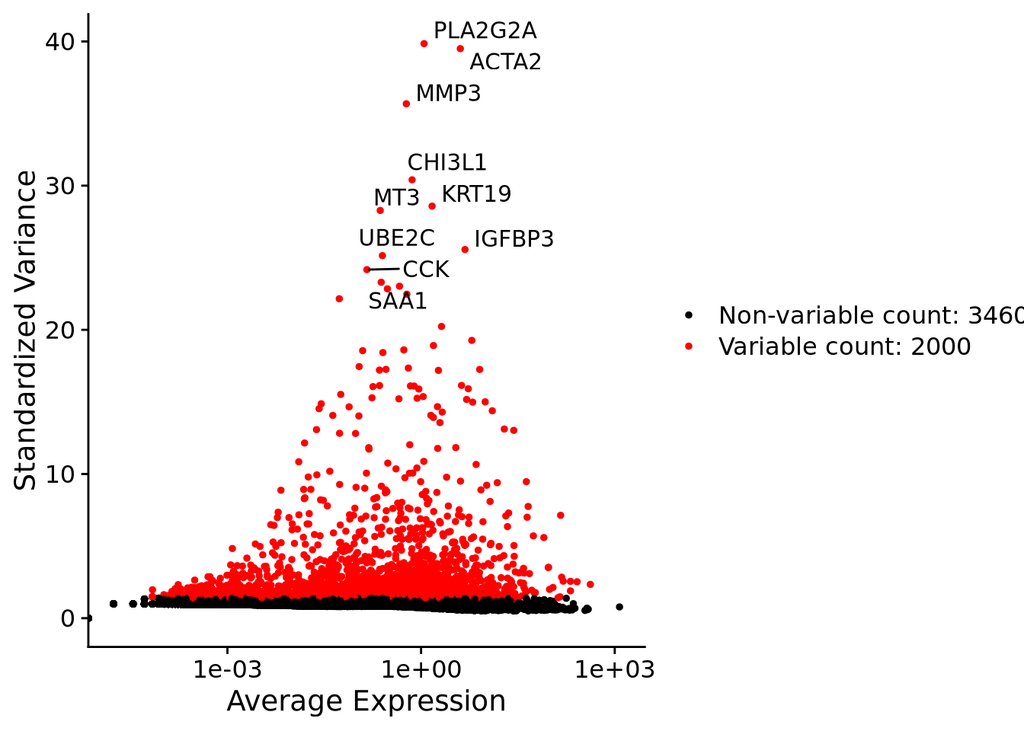

```r
plot2
```

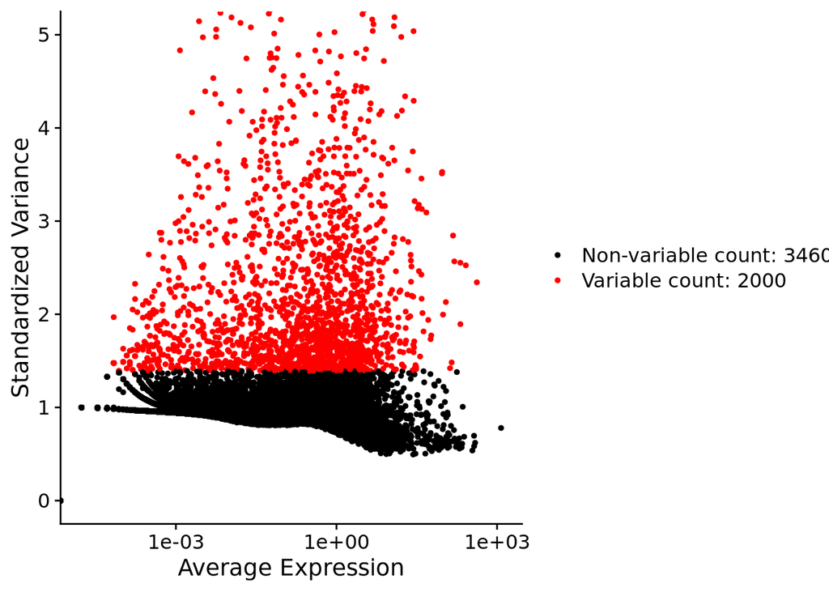

```r
plot1 + coord_cartesian(y=c(0,5))
```

## PCA

```r
filt = RunPCA (filt, ndims.print=2)
```

```
## PC_ 2
## Positive:  MT1X, MT1E, SNAI2, MT2A, AOX1, SAMHD1, MORF4L2, TSC22D3, C1orf21, HSD11B1
##     RASSF4, PNRC1, FKBP5, TMEM64, HIPK2, SLC44A1, ANGPTL1, EDNRB, STXBP6, TCEAL4
##     SH3PXD2B, ZFP36L1, AKR1C1, DCN, RAB31, CRLF1, NFIL3, MTRNR2L12, ARHGEF19, PDLIM1
## Negative:  ALDOA, VIM, MIR4435-2HG, CYTOR, DYNLRB1, ADAM12, LMNA, SNRPD3, HMGA1, MYL9
##     LIMA1, FKBP2, RPS10-NUDT3, UACA, GREM1, LMO7, U2AF1, PLS3, RPL22L1, FHL1
##     COLEC12, S100A4, C12orf75, ADIRF, ANXA5, CNN2, MYH9, FRMD6, MARCKS, IER3
```

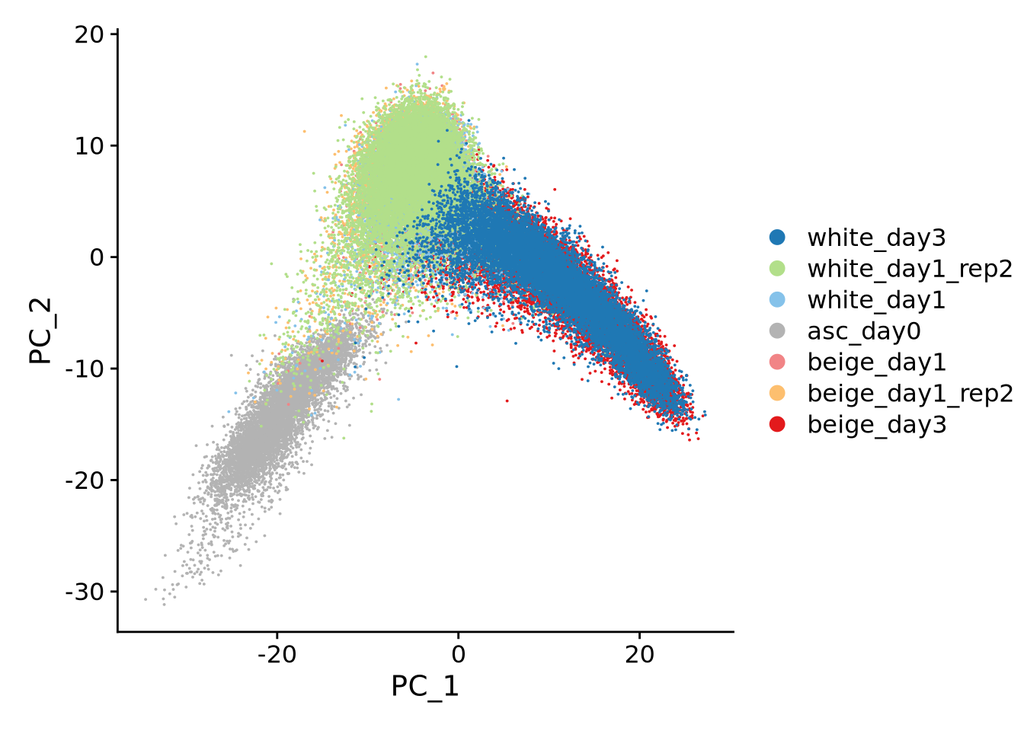

```r
DimPlot(filt, reduction = "pca", cols = pal)
```

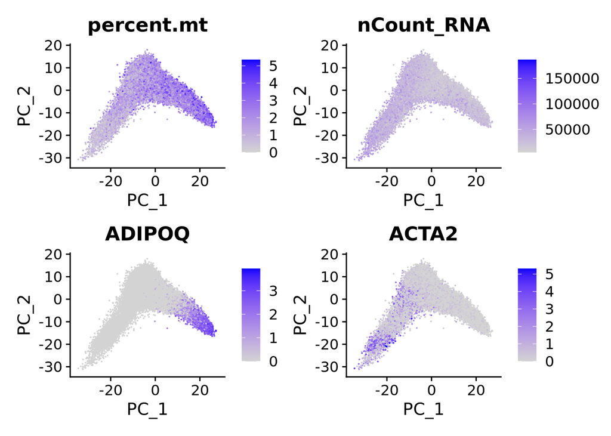

```r
FeaturePlot(filt, features= c("percent.mt","nCount_RNA","ADIPOQ","ACTA2"))
```

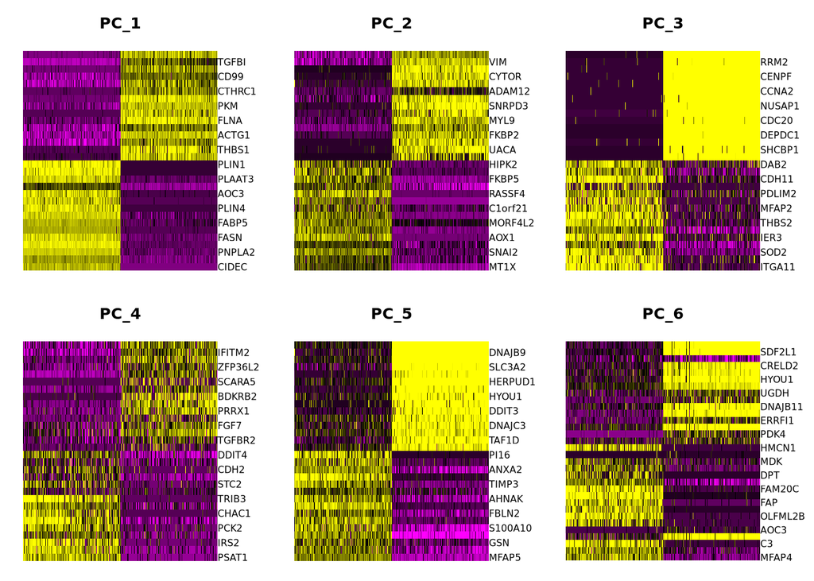

```r
DimHeatmap(filt, dims = 1:6, cells = 500, balanced = TRUE)
```

### Determine the dimensionality

They encourage to complete downstream analyses with different numbers of PCs.

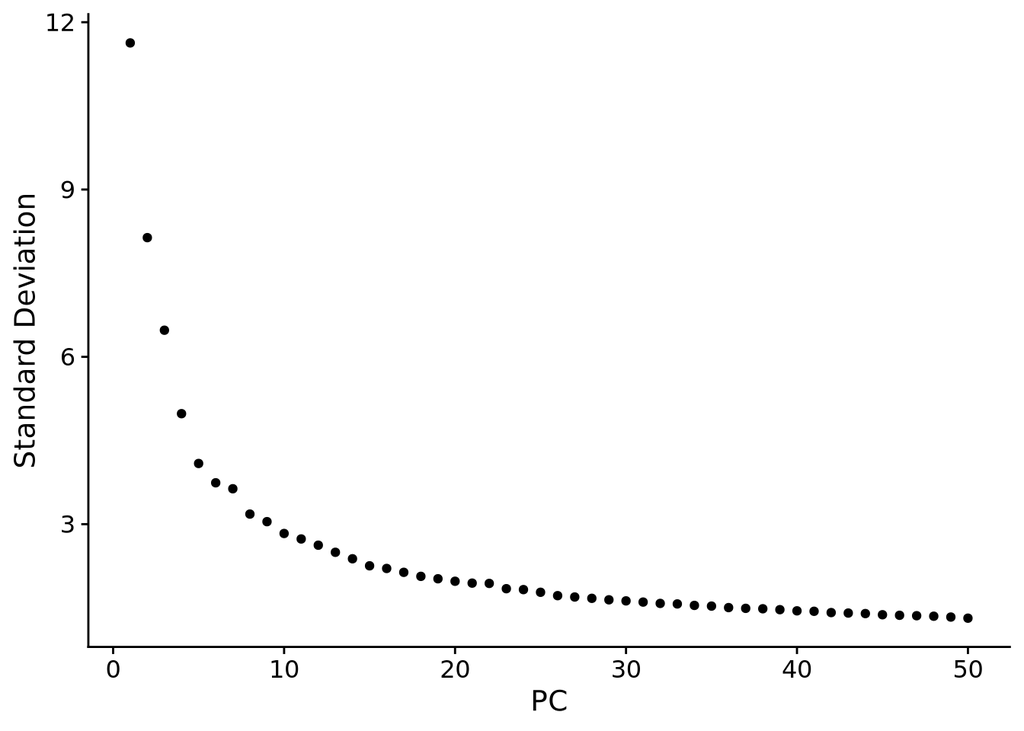

```r
ElbowPlot(filt, ndims = 50)
```

## Cluster

```r
filt <- FindNeighbors(filt, dims = 1:20)
filt <- FindClusters(filt, resolution = 0.5)
```

```
## Modularity Optimizer version 1.3.0 by Ludo Waltman and Nees Jan van Eck
##
## Number of nodes: 57882
## Number of edges: 1619135
##
## Running Louvain algorithm...
## Maximum modularity in 10 random starts: 0.8781
## Number of communities: 13
## Elapsed time: 25 seconds
```

```
## 1 singletons identified. 12 final clusters.
```

```r
table(filt@meta.data$seurat_clusters)
```

```
##
##     0     1     2     3     4     5     6     7     8     9    10    11
## 13056  9219  8830  7345  6894  4372  3330  2272  1168   566   461   369
```

### Cluster composition

```r
composition = group_by(filt@meta.data, orig.ident,seurat_clusters) %>% count()
composition = composition[order(composition$n, decreasing = T),]
colnames(composition) = c("orig.ident","seurat_clusters","n_cells")
head(composition)
```

```
## # A tibble: 6 × 3
## # Groups:   orig.ident, seurat_clusters [6]
##   orig.ident      seurat_clusters n_cells
##   <fct>           <fct>             <int>
## 1 white_day1_rep2 0                  7288
## 2 asc_day0        4                  6891
## 3 beige_day3      1                  4922
## 4 white_day3      1                  4161
## 5 beige_day3      3                  3924
## 6 white_day3      3                  3398
```

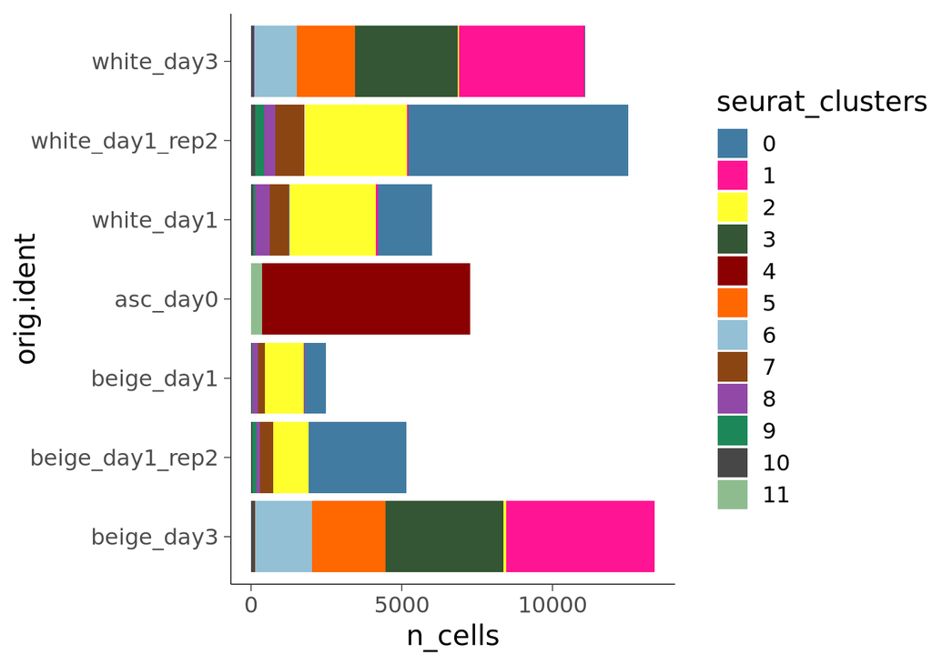

```r
ggplot(composition) + geom_bar(stat="identity",aes(y=orig.ident, x=n_cells, fill=seurat_clusters)) +
  scale_y_discrete(limits=rev) + scale_fill_manual(values=clusters)
```

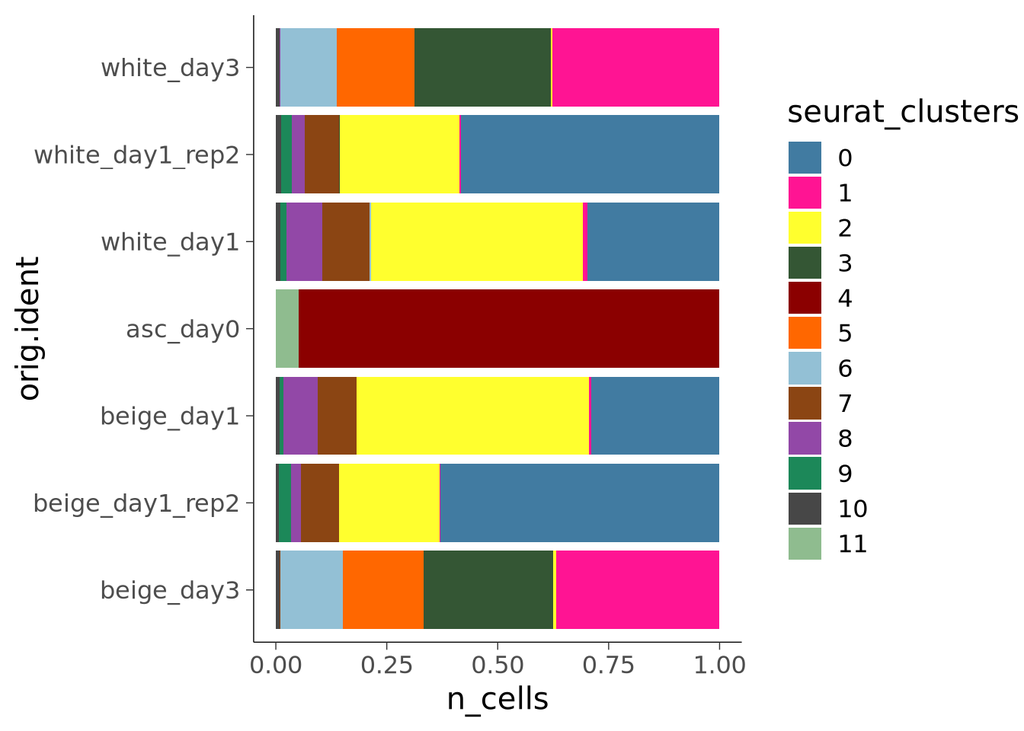

```r
ggplot(composition) + geom_bar(stat="identity",aes(y=orig.ident, x=n_cells, fill=seurat_clusters), position = "fill") +
  scale_y_discrete(limits=rev)+ scale_fill_manual(values=clusters)
```

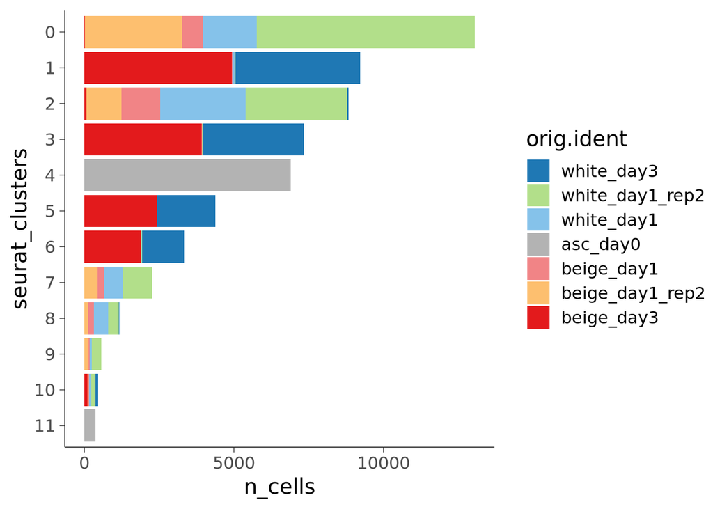

```r
ggplot(composition) + geom_bar(stat="identity",aes(fill=orig.ident, x=n_cells, y=seurat_clusters)) +
  scale_y_discrete(limits=rev)+ scale_fill_manual(values=pal)
```

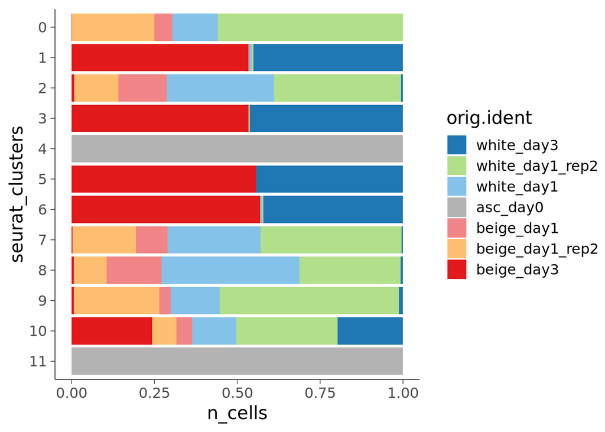

```r
ggplot(composition) + geom_bar(stat="identity",aes(fill=orig.ident, x=n_cells, y=seurat_clusters), position = "fill") +
  scale_y_discrete(limits=rev) + scale_fill_manual(values=pal)
```

## UMAP

```r
filt = RunUMAP(filt, dims=1:20)
```

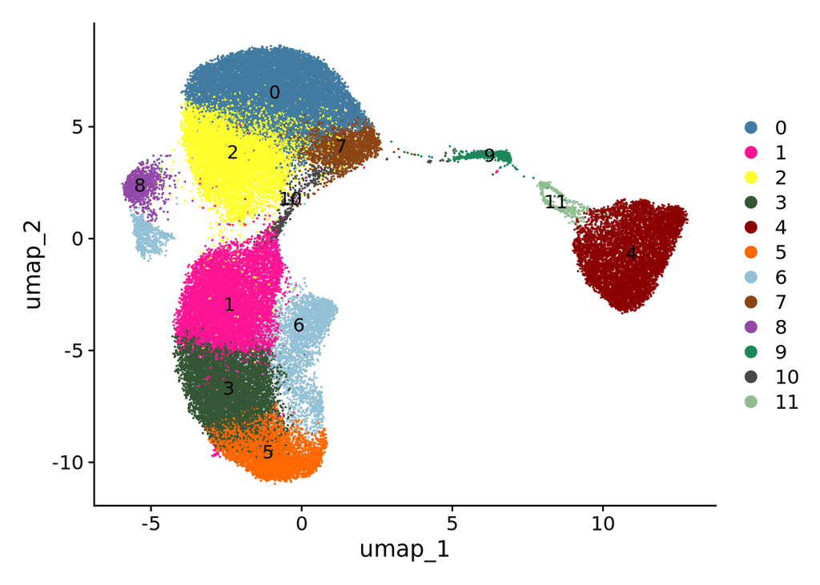

```r
DimPlot(filt, reduction="umap", label=T, shuffle = T, cols=clusters)
```

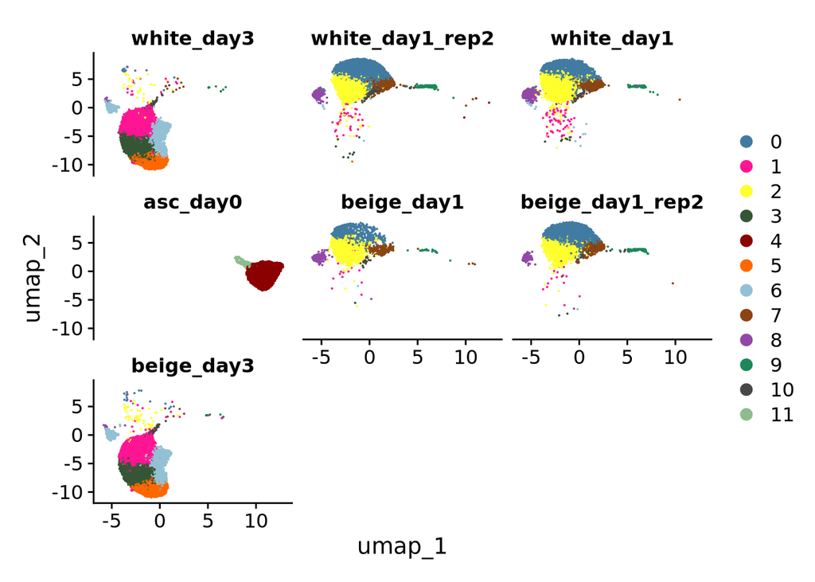

```r
DimPlot(filt, reduction="umap", split.by = "orig.ident", ncol=3, shuffle = T,  cols=clusters)
```

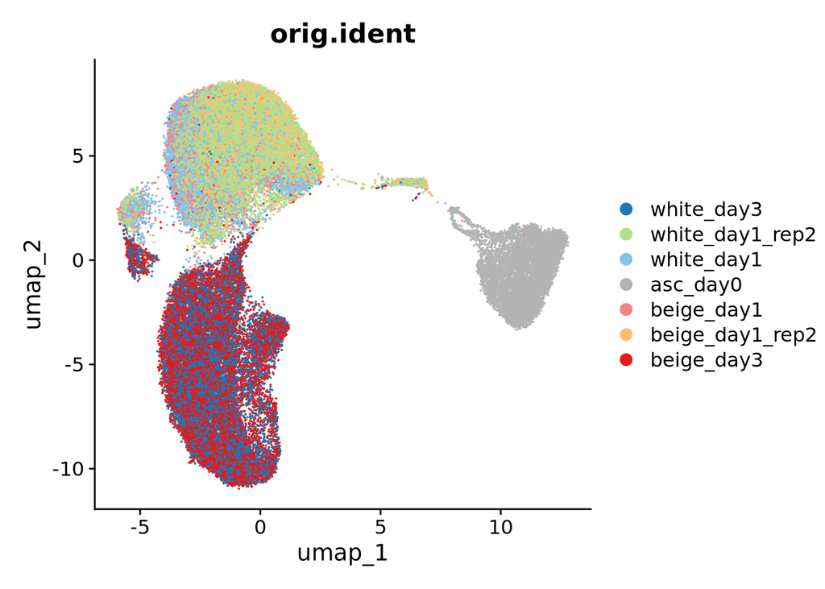

```r
DimPlot(filt, group.by="orig.ident", cols=pal, shuffle = T)
```

## t-SNE

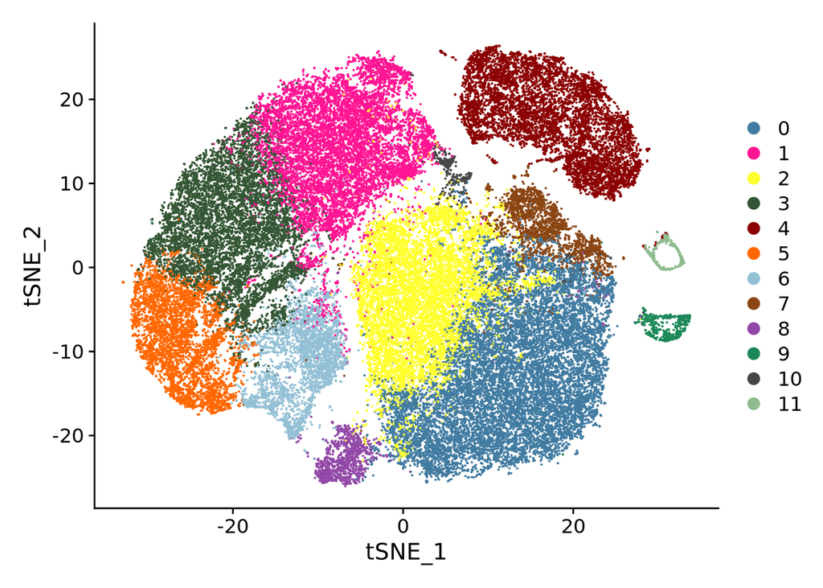

```r
filt = RunTSNE(filt, reduction="pca", dims=1:30)
DimPlot(filt, reduction = "tsne",shuffle=T,  cols=clusters)
```

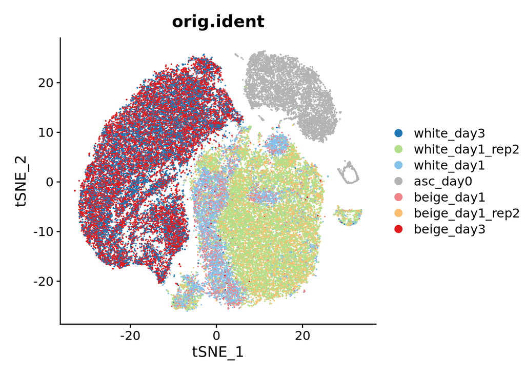

```r
DimPlot(filt, reduction = "tsne", group.by= "orig.ident", shuffle = T, cols=pal)
```

## Find biomarkers

Min.pct sets the minimum percentage of cells for a marker to be found in

Does densify, which increases speed at the cost of memory help?

```r
norm.markers = FindAllMarkers(filt, only.pos = T, min.pct=0.25,
                              logfc.threshold = 0.5, densify=T)
head(norm.markers); dim(norm.markers)
```

```
##           p_val avg_log2FC pct.1 pct.2 p_val_adj cluster      gene
## MTRNR2L12     0   1.906608 0.807 0.202         0       0 MTRNR2L12
## DKK1          0   3.109277 0.875 0.314         0       0      DKK1
## STXBP6        0   2.371965 0.856 0.300         0       0    STXBP6
## ALOX15B       0   3.573119 0.646 0.095         0       0   ALOX15B
## SORBS2        0   3.307024 0.665 0.129         0       0    SORBS2
## NEDD4         0   2.297454 0.815 0.317         0       0     NEDD4
```

```
## [1] 15683     7
```

```r
top.markers = as.data.frame(norm.markers %>%
    group_by(cluster) %>%
    slice_max(n = 2, order_by = avg_log2FC))
top.markers
```

```
##    p_val avg_log2FC pct.1 pct.2 p_val_adj cluster      gene
## 1      0   3.573119 0.646 0.095         0       0   ALOX15B
## 2      0   3.393745 0.682 0.228         0       0     SOCS1
## 3      0   2.077077 0.463 0.180         0       1    SCARA5
## 4      0   2.071686 0.301 0.101         0       1     FABP3
## 5      0   2.297485 0.292 0.119         0       2      IGF1
## 6      0   1.948827 0.344 0.133         0       2     KCNJ8
## 7      0   2.511836 0.871 0.252         0       3      UCP2
## 8      0   2.374860 0.518 0.136         0       3    GPBAR1
## 9      0   6.759506 0.462 0.009         0       4      WNT2
## 10     0   6.656058 0.468 0.022         0       4     CEMIP
## 11     0   5.941622 0.459 0.017         0       5      PCK1
## 12     0   4.877534 0.444 0.023         0       5       GPT
## 13     0   5.739140 0.353 0.015         0       6     DERL3
## 14     0   2.851703 0.625 0.280         0       6    SEC11C
## 15     0   2.226416 0.732 0.247         0       7    SPOCD1
## 16     0   2.204015 0.288 0.065         0       7   CARMIL2
## 17     0   4.752973 0.349 0.019         0       8     CDH15
## 18     0   3.894465 0.999 0.581         0       8    SDF2L1
## 19     0   8.094196 0.935 0.012         0       9     UBE2C
## 20     0   7.788750 0.961 0.018         0       9      RRM2
## 21     0   5.202958 0.544 0.047         0      10   SLC2A12
## 22     0   5.153950 0.547 0.027         0      10    FENDRR
## 23     0   8.610070 0.314 0.003         0      11 HIST1H2AJ
## 24     0   7.344900 0.691 0.007         0      11  APOBEC3B
```

Visualisation methods

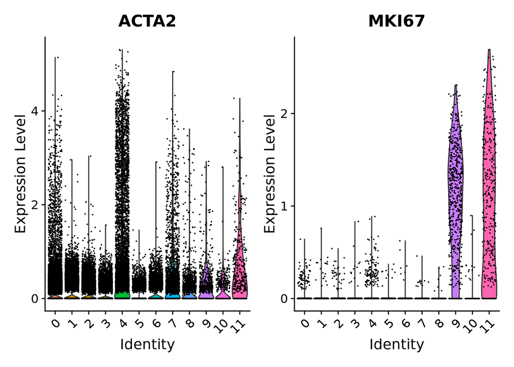

```r
VlnPlot(filt, features = c("ACTA2","MKI67"))
```

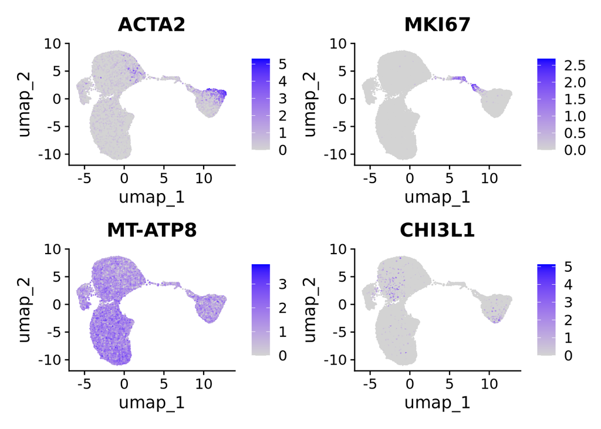

```r
FeaturePlot(filt, features = c("ACTA2","MKI67","MT-ATP8","CHI3L1"))
```